# Practica PCA

## Exploración Descriptiva

A continuación vamos a sacar los principales estadísticos descriptivos ahora que tenemos los datos transformados.

**Originales**

```r
summary(datos)
```

```
##     ZPOBDENS          ZTMINFAN          ZESPVIDA          ZPOBURB
##  Min.   :-1.0778   Min.   :-1.1026   Min.   :-2.1453   Min.   :-1.7697
##  1st Qu.:-0.8497   1st Qu.:-0.9586   1st Qu.:-0.7460   1st Qu.:-0.7320
##  Median :-0.1616   Median :-0.3931   Median : 0.2781   Median : 0.1268
##  Mean   : 0.0000   Mean   : 0.0000   Mean   : 0.0000   Mean   : 0.0000
##  3rd Qu.: 0.5547   3rd Qu.: 0.8985   3rd Qu.: 0.9033   3rd Qu.: 0.8148
##  Max.   : 2.8616   Max.   : 1.9048   Max.   : 1.2486   Max.   : 1.5096
##
##     ZTMEDICO          ZPAGRICU          ZPSERVI            ZTLIBROP
##  Min.   :-1.1473   Min.   :-1.2342   Min.   :-1.88521   Min.   :-0.9696
##  1st Qu.:-0.8829   1st Qu.:-0.8480   1st Qu.:-0.72858   1st Qu.:-0.9240
##  Median :-0.2916   Median :-0.2134   Median : 0.03541   Median :-0.3237
##  Mean   : 0.0000   Mean   : 0.0000   Mean   : 0.00000   Mean   : 0.0000
##  3rd Qu.: 0.8694   3rd Qu.: 0.7115   3rd Qu.: 0.85176   3rd Qu.: 0.7736
##  Max.   : 2.3717   Max.   : 1.9052   Max.   : 1.62885   Max.   : 2.4024
##                                                         NA's   :1
##     ZTEJERCI           ZTPOBACT          ZTENERGI
##  Min.   :-0.86586   Min.   :-2.1341   Min.   :-0.9507
##  1st Qu.:-0.59889   1st Qu.:-0.6735   1st Qu.:-0.7813
##  Median :-0.20626   Median :-0.1067   Median :-0.3900
##  Mean   : 0.00000   Mean   : 0.0000   Mean   : 0.0000
##  3rd Qu.: 0.07996   3rd Qu.: 0.8789   3rd Qu.: 0.5828
##  Max.   : 4.42620   Max.   : 1.7045   Max.   : 2.7498
##
```

**Tratados**

```r
summary(datos_pca)
```

```
##     ZPOBDENS           ZTMINFAN          ZESPVIDA          ZPOBURB
##  Min.   :-1.07783   Min.   :-1.1026   Min.   :-2.1453   Min.   :-1.7697
##  1st Qu.:-0.84968   1st Qu.:-0.9586   1st Qu.:-0.7460   1st Qu.:-0.7320
##  Median :-0.16160   Median :-0.3931   Median : 0.2781   Median : 0.1268
##  Mean   :-0.08672   Mean   : 0.0000   Mean   : 0.0000   Mean   : 0.0000
##  3rd Qu.: 0.40244   3rd Qu.: 0.8985   3rd Qu.: 0.9033   3rd Qu.: 0.8148
##  Max.   : 2.15204   Max.   : 1.9048   Max.   : 1.2486   Max.   : 1.5096
##     ZTMEDICO          ZPAGRICU          ZPSERVI            ZTLIBROP
##  Min.   :-1.1473   Min.   :-1.2342   Min.   :-1.88521   Min.   :-0.9696
##  1st Qu.:-0.8829   1st Qu.:-0.8480   1st Qu.:-0.72858   1st Qu.:-0.9145
##  Median :-0.2916   Median :-0.2134   Median : 0.03541   Median :-0.2442
##  Mean   : 0.0000   Mean   : 0.0000   Mean   : 0.00000   Mean   : 0.0000
##  3rd Qu.: 0.8694   3rd Qu.: 0.7115   3rd Qu.: 0.85176   3rd Qu.: 0.6923
##  Max.   : 2.3717   Max.   : 1.9052   Max.   : 1.62885   Max.   : 2.4024
##     ZTEJERCI           ZTPOBACT          ZTENERGI
##  Min.   :-0.86586   Min.   :-2.1341   Min.   :-0.9507
##  1st Qu.:-0.59889   1st Qu.:-0.6735   1st Qu.:-0.7813
##  Median :-0.28969   Median :-0.1067   Median :-0.3900
##  Mean   :-0.28969   Mean   : 0.0000   Mean   :-0.1690
##  3rd Qu.:-0.04621   3rd Qu.: 0.8789   3rd Qu.: 0.3346
##  Max.   : 0.68708   Max.   : 1.7045   Max.   : 1.5672
```

# Supuestos de correlación

Comenzamos comprobando si existe correlación entre las variables:

```r
cor(datos_pca)
```

```
##             ZPOBDENS   ZTMINFAN   ZESPVIDA     ZPOBURB   ZTMEDICO     ZPAGRICU
## ZPOBDENS  1.00000000 -0.2109635  0.1735014  0.05132529  0.0525974 -0.018865672
## ZTMINFAN -0.21096354  1.0000000 -0.9668834 -0.75749544 -0.7509189  0.752161039
## ZESPVIDA  0.17350137 -0.9668834  1.0000000  0.78714604  0.7361282 -0.753537421
## ZPOBURB   0.05132529 -0.7574954  0.7871460  1.00000000  0.6353621 -0.938022359
## ZTMEDICO  0.05259740 -0.7509189  0.7361282  0.63536205  1.0000000 -0.674513147
## ZPAGRICU -0.01886567  0.7521610 -0.7535374 -0.93802236 -0.6745131  1.000000000
## ZPSERVI  -0.05804281 -0.5901653  0.6121270  0.89001519  0.4446255 -0.907218449
## ZTLIBROP  0.23071577 -0.7157201  0.7004692  0.66106622  0.6093143 -0.666850181
## ZTEJERCI  0.05154113 -0.0254503  0.1017843  0.03566091  0.1513290 -0.007128371
## ZTPOBACT  0.23749261 -0.6032470  0.5411995  0.15488847  0.5336484 -0.147150671
## ZTENERGI  0.17123880 -0.7155678  0.6651297  0.61549363  0.7507638 -0.688730826
##              ZPSERVI   ZTLIBROP     ZTEJERCI    ZTPOBACT   ZTENERGI
## ZPOBDENS -0.05804281  0.2307158  0.051541133  0.23749261  0.1712388
## ZTMINFAN -0.59016525 -0.7157201 -0.025450301 -0.60324698 -0.7155678
## ZESPVIDA  0.61212697  0.7004692  0.101784303  0.54119951  0.6651297
## ZPOBURB   0.89001519  0.6610662  0.035660910  0.15488847  0.6154936
## ZTMEDICO  0.44462549  0.6093143  0.151329048  0.53364837  0.7507638
## ZPAGRICU -0.90721845 -0.6668502 -0.007128371 -0.14715067 -0.6887308
## ZPSERVI   1.00000000  0.5044833 -0.173017490 -0.05616141  0.4159030
## ZTLIBROP  0.50448334  1.0000000  0.113918652  0.41591469  0.6602394
## ZTEJERCI -0.17301749  0.1139187  1.000000000 -0.07216152  0.1076248
## ZTPOBACT -0.05616141  0.4159147 -0.072161520  1.00000000  0.6004197
## ZTENERGI  0.41590296  0.6602394  0.107624821  0.60041968  1.0000000
```

El contraste de esfericidad de Bartlett permite comprobar si las correlaciones son distintas de 0 de modo significativo. La hipótesis nula es que det(R)=1. La función “cortest.bartlett” del paquete “pysch” realiza este test. Esta función trabaja con datos normalizados.

```r
library(psych)
# Se normalizan los datos
datos_normalizados<-scale(datos_pca)
# Se hace el test de esfericidad
cortest.bartlett(cor(datos_normalizados))
```

```
## $chisq
## [1] 1285.077
##
## $p.value
## [1] 1.141378e-232
##
## $df
## [1] 55
```

Para estos datos se obtiene un test significativo de modo que se rechaza la hipótesis nula y por tanto los datos no están incorrelados. Aún así, seguiremos adelante y si algo no funciona puede deberse a esto.

# Análisis exploratorio de los datos

Como ya hemos imputado los valores perdidos y eliminado los outliers no hace falta repetir el procedimiento.

# Estudio de posibilidad de reducción de la dimensión

Vamos a realizar un análisis de componentes principales (PCA). La función “prcomp” del paquete base de R realiza este análisis.

Pasamos los parámetros “scale” y “center” a TRUE para considerar los datos originales normalizados. Además, el campo “rotation” del objeto PCA es una matriz cuyas columnas son los coeficientes de las componentes principales. Finalmente, en el campo “sdev” del mismo objeto obtenemos la información sobre desviaciones típicas de cada componente principal, proporción de varianza explicada y acumulada.

```r
PCA<-prcomp(datos_pca, scale=T, center = T)
PCA$rotation
```

```
##                  PC1         PC2         PC3          PC4         PC5
## ZPOBDENS  0.06796131  0.39036079  0.07578571 -0.873056137  0.05981546
## ZTMINFAN -0.37529798 -0.11573027 -0.08212636 -0.014741875  0.41788865
## ZESPVIDA  0.37165513  0.07270402 -0.00407411  0.012970861 -0.53281544
## ZPOBURB   0.35808785 -0.29124050 -0.06094609 -0.113795410 -0.05152603
## ZTMEDICO  0.33374417  0.13909259 -0.09587119  0.280930962  0.15782496
## ZPAGRICU -0.36224935  0.29940891  0.04348437  0.061235615 -0.15998056
## ZPSERVI   0.29607632 -0.48878963  0.09183567 -0.148420697 -0.03064997
## ZTLIBROP  0.32594252  0.08892433 -0.07078859 -0.135187927  0.28062939
## ZTEJERCI  0.02397325  0.17948476 -0.93319975 -0.006241743 -0.12518016
## ZTPOBACT  0.20289865  0.56167354  0.29659750  0.281932179 -0.11796713
## ZTENERGI  0.33155119  0.20152127 -0.02054058  0.148110844  0.61275026
##                  PC6         PC7         PC8          PC9        PC10
## ZPOBDENS -0.24337351  0.09619809 -0.04353317  0.022846323 -0.01646372
## ZTMINFAN -0.01756878  0.05245475 -0.39097670 -0.157260993 -0.47091956
## ZESPVIDA  0.03028763 -0.04105430  0.29289664 -0.091799724 -0.54354628
## ZPOBURB  -0.07065324 -0.10651593 -0.29868358 -0.792450091  0.16228759
## ZTMEDICO -0.36060911  0.78403566 -0.06560314  0.001929436 -0.06125296
## ZPAGRICU  0.13248858  0.09343760 -0.01200167 -0.325592955 -0.48343682
## ZPSERVI  -0.07352269 -0.09280074 -0.37422057  0.449245272 -0.39418278
## ZTLIBROP  0.85707761  0.21913126 -0.01229527  0.015266047 -0.02755826
## ZTEJERCI -0.02870986 -0.16141551 -0.18218984  0.127931321  0.01085377
## ZTPOBACT  0.02948798 -0.25103160 -0.61023870  0.097328148  0.08409493
## ZTENERGI -0.21278600 -0.45367225  0.34643517 -0.066593066 -0.23535405
##                  PC11
## ZPOBDENS -0.016686681
## ZTMINFAN -0.511610948
## ZESPVIDA -0.424556791
## ZPOBURB   0.088144761
## ZTMEDICO  0.058614024
## ZPAGRICU  0.617855535
## ZPSERVI   0.361609762
## ZTLIBROP  0.008370356
## ZTEJERCI  0.063899183
## ZTPOBACT -0.095710436
## ZTENERGI  0.143880098
```

```r
PCA$sdev
```

```
##  [1] 2.4818030 1.2805818 1.0311152 0.9515420 0.6448055 0.6027181 0.4818699
##  [8] 0.3354192 0.2491626 0.1641974 0.1390789
```

```r
summary(PCA)
```

```
## Importance of components:
##                           PC1    PC2     PC3     PC4    PC5     PC6     PC7
## Standard deviation     2.4818 1.2806 1.03112 0.95154 0.6448 0.60272 0.48187
## Proportion of Variance 0.5599 0.1491 0.09665 0.08231 0.0378 0.03302 0.02111
## Cumulative Proportion  0.5599 0.7090 0.80568 0.88799 0.9258 0.95881 0.97992
##                            PC8     PC9    PC10    PC11
## Standard deviation     0.33542 0.24916 0.16420 0.13908
## Proportion of Variance 0.01023 0.00564 0.00245 0.00176
## Cumulative Proportion  0.99015 0.99579 0.99824 1.00000
```

Representamos ahora la proporción de varianza explicada y acumulada:

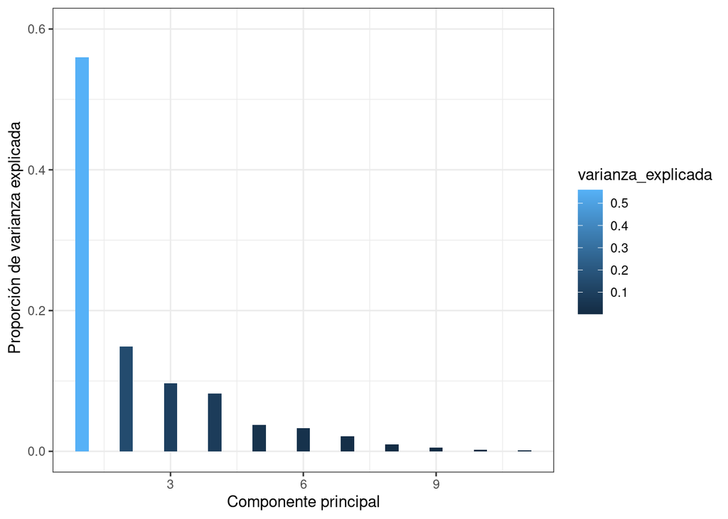

```r
library("ggplot2")
# El siguiente gráfico muestra la proporción de varianza explicada
varianza_explicada <- PCA$sdev^2 / sum(PCA$sdev^2)
ggplot(data = data.frame(varianza_explicada, pc = 1:11),
       aes(x = pc, y = varianza_explicada, fill=varianza_explicada )) +
  geom_col(width = 0.3) +
  scale_y_continuous(limits = c(0,0.6)) + theme_bw() +
  labs(x = "Componente principal", y= " Proporción de varianza explicada")
```

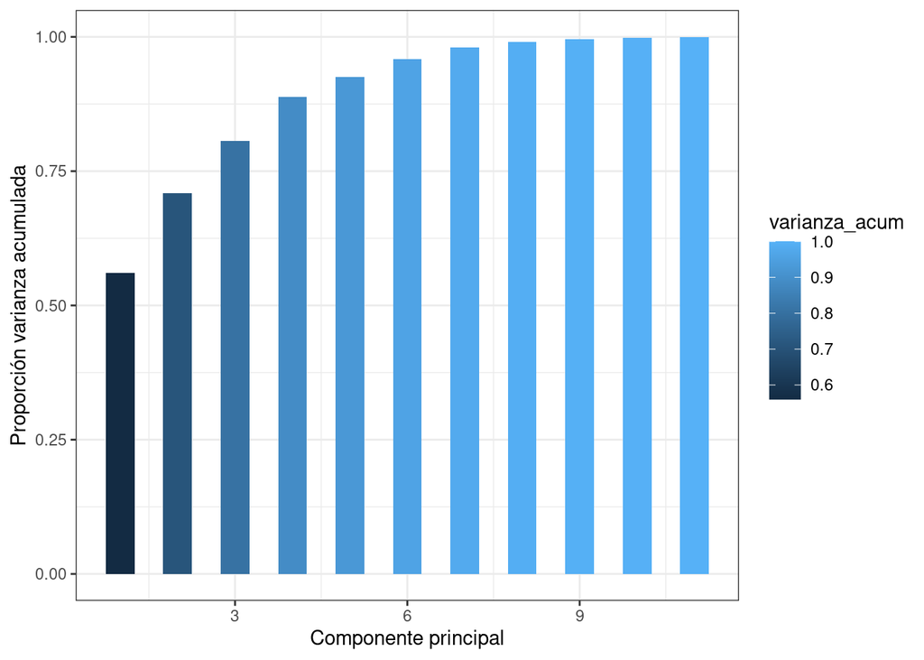

```r
# El siguiente gráfico muestra la proporción de varianza explicada
varianza_acum<-cumsum(varianza_explicada)
ggplot( data = data.frame(varianza_acum, pc = 1:11),
        aes(x = pc, y = varianza_acum ,fill=varianza_acum )) +
  geom_col(width = 0.5) +
  scale_y_continuous(limits = c(0,1)) +
  theme_bw() +
  labs(x = "Componente principal",
       y = "Proporción varianza acumulada")
```

```r
PCA$sdev^2
```

```
##  [1] 6.15934602 1.63988972 1.06319852 0.90543213 0.41577420 0.36326910
##  [7] 0.23219856 0.11250601 0.06208202 0.02696079 0.01934294
```

```r
mean(PCA$sdev^2)
```

```
## [1] 1
```

En este caso la media es 1, luego se escogerían la primera, segunda y tercera. Esto son, 3 componentes principales.

Ahora vamos a representar las componentes principales, realizando una comparativa entre la primera y segunda componente principal analizando qué variables tienen más peso para la definición de cada componente principal, después entre la primera y la tercera y finalmente entre la segunda y tercera.

```r
library("factoextra")
```

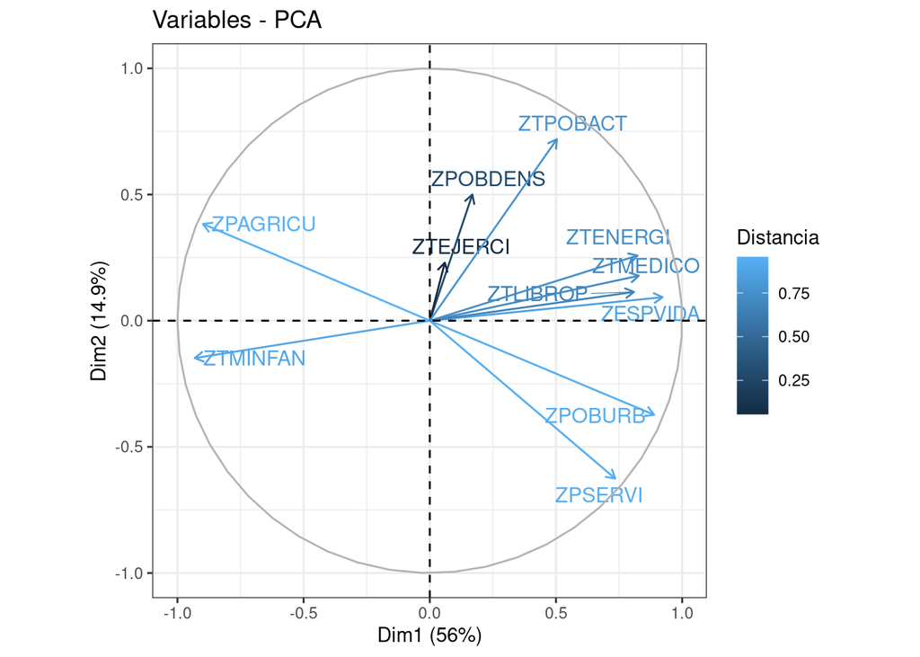

```r
fviz_pca_var(PCA,
             repel=TRUE,col.var="cos2",
             legend.title="Distancia")+theme_bw()
```

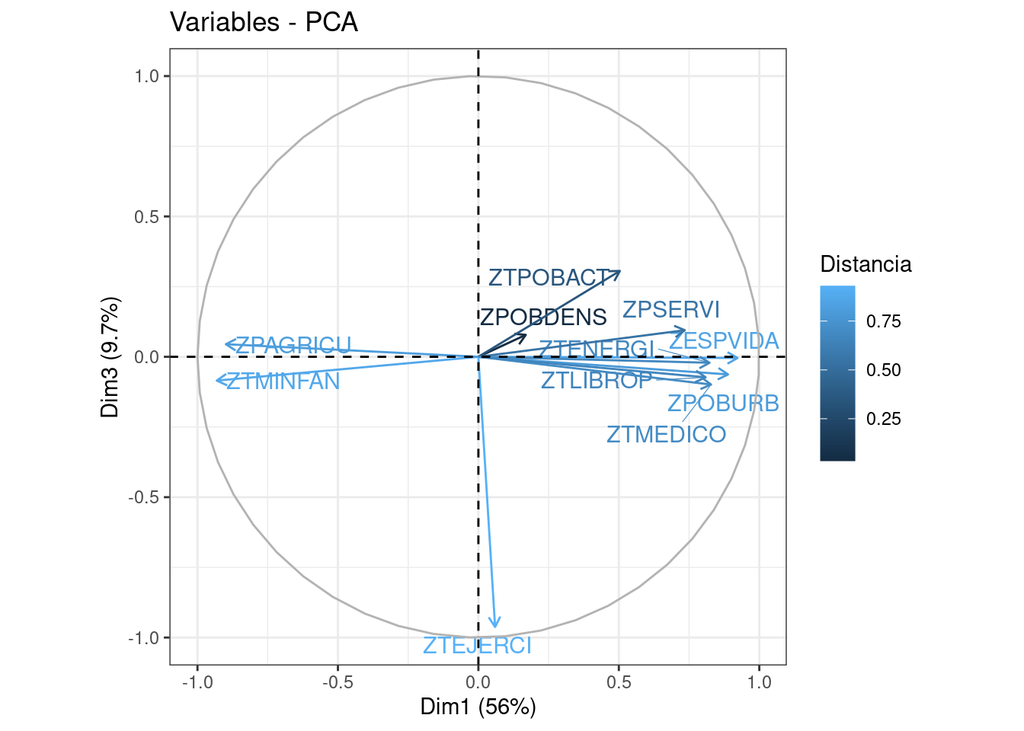

```r
fviz_pca_var(PCA,axes=c(1,3),
             repel=TRUE,col.var="cos2",
             legend.title="Distancia")+theme_bw()
```

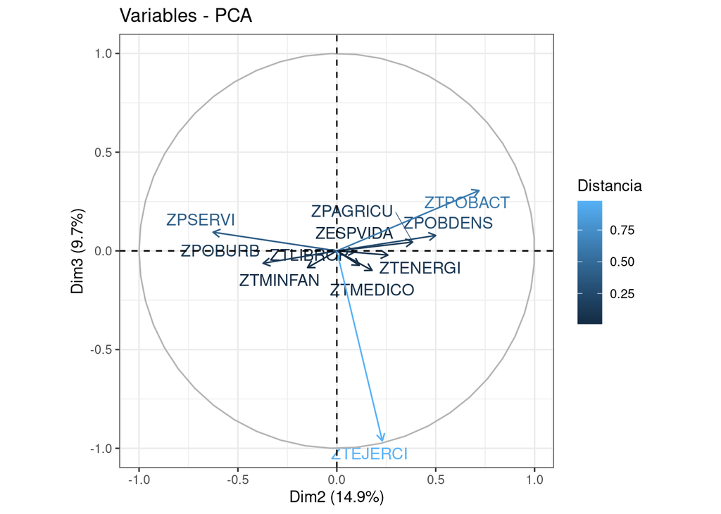

```r
fviz_pca_var(PCA,axes=c(2,3),
             repel=TRUE,col.var="cos2",
             legend.title="Distancia")+theme_bw()
```

Es posible también representar las observaciones de los objetos junto con las componentes principales mediante la orden “contrib” de la función “fviz_pca_ind”, así como identificar con colores aquellas observaciones que mayor varianza explican de las componentes principales.

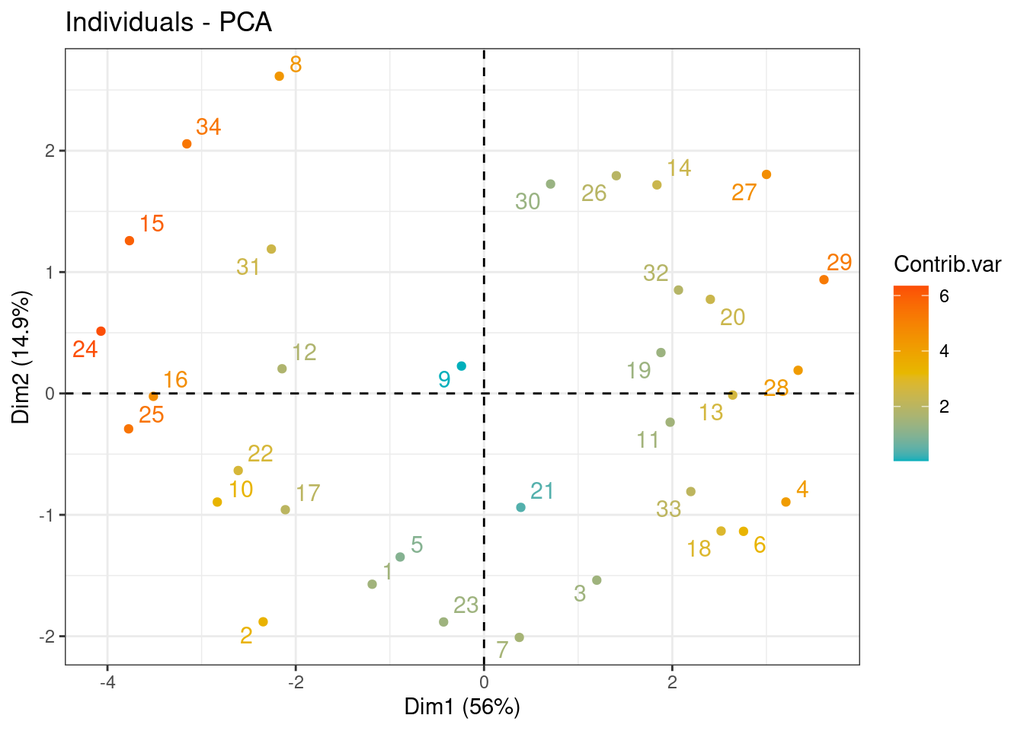

```r
# Observaciones en la primera y segunda componente principal
fviz_pca_ind(PCA,col.ind = "contrib",
             gradient.cols = c("#00AFBB", "#E7B800", "#FC4E07"),
             repel=TRUE,legend.title="Contrib.var")+theme_bw()
```

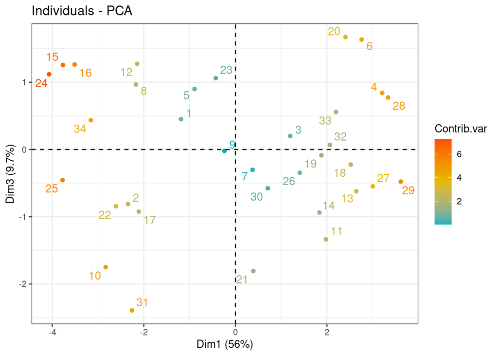

```r
# Observaciones en la primera y tercera componente principal
fviz_pca_ind(PCA,axes=c(1,3),col.ind = "contrib",
             gradient.cols = c("#00AFBB", "#E7B800", "#FC4E07"),
             repel=TRUE,legend.title="Contrib.var")+theme_bw()
```

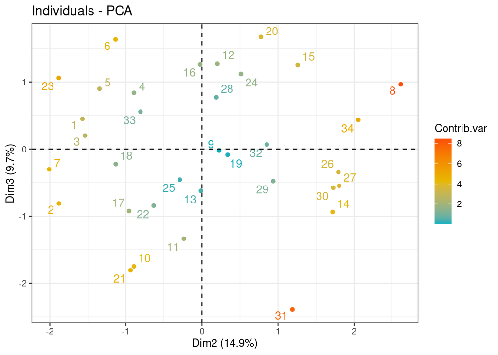

```r
# Observaciones en la segunda y tercera componente principal
fviz_pca_ind(PCA,axes=c(2,3),col.ind = "contrib",
             gradient.cols = c("#00AFBB", "#E7B800", "#FC4E07"),
             repel=TRUE,legend.title="Contrib.var")+theme_bw()
```

Además haremos una representación conjunta de variables y observaciones que relaciona visualmente las posibles relaciones entre las observaciones, las contribuciones de los individuos a las varianzas de las componentes y el peso de las variables en cada componentes principal.

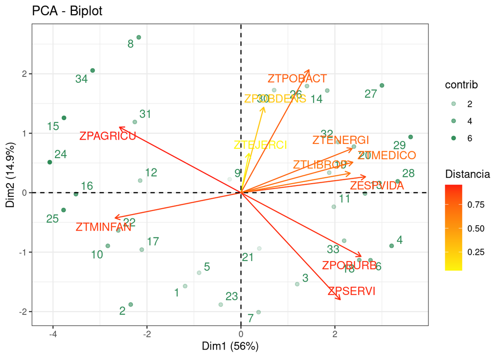

```r
# Variables y observaciones en las 1?  y 2? componente principal
fviz_pca(PCA,
         alpha.ind ="contrib", col.var = "cos2",col.ind="seagreen",
         gradient.cols = c("#FDF50E", "#FD960E", "#FD1E0E"),
         repel=TRUE,
         legend.title="Distancia")+theme_bw()
```

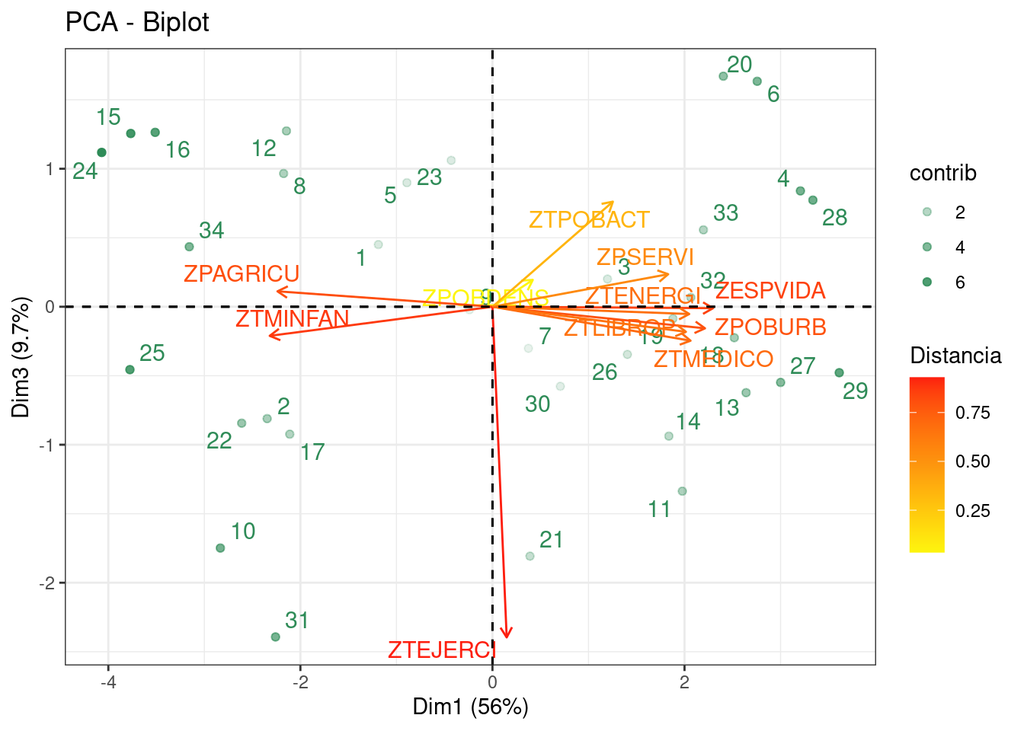

```r
# Variables y observaciones en las 1?  y 3? componente principal
fviz_pca(PCA,axes=c(1,3),
         alpha.ind ="contrib", col.var = "cos2",col.ind="seagreen",
         gradient.cols = c("#FDF50E", "#FD960E", "#FD1E0E"),
         repel=TRUE,
         legend.title="Distancia")+theme_bw()
```

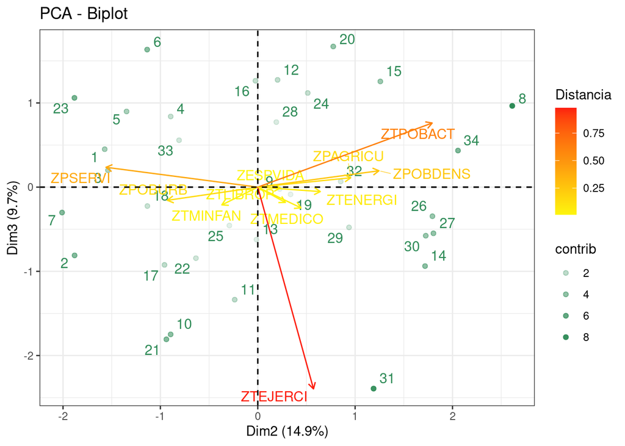

```r
# Variables y observaciones en las 2  y 3? componente principal
fviz_pca(PCA,axes=c(2,3),
         alpha.ind ="contrib", col.var = "cos2",col.ind="seagreen",
         gradient.cols = c("#FDF50E", "#FD960E", "#FD1E0E"),
         repel=TRUE,
         legend.title="Distancia")+theme_bw()
```

Por último, ya que el objeto de este estudio es reducir la dimensión de las variables utilizadas, es posible obtener las coordenadas de los datos originales tipificados en el nuevo sistema de referencia. De hecho lo tenemos almacenado desde que utilizamos la función prcomp para crear la variable PCA

```r
head(PCA$x,n=3)
```

```
##            PC1       PC2        PC3       PC4        PC5        PC6        PC7
## [1,] -1.187951 -1.571749  0.4504449 0.3781493  1.4228328 -0.2719916 -0.6235956
## [2,] -2.346246 -1.881066 -0.8108192 0.2014503  0.4528028 -0.2176741 -0.1130183
## [3,]  1.197924 -1.538337  0.2007784 0.8972738 -0.3885080 -0.7714447  0.8072288
##              PC8        PC9       PC10          PC11
## [1,] -0.09144981  0.3475349  0.3629623  0.0009993838
## [2,]  0.67613362  0.3189091 -0.2221354 -0.1452388044
## [3,] -0.15129705 -0.4099810  0.1343895 -0.0562911808
```

# Reducción de dimensión mediante variables latentes

Como ya hemos comprobado las correlaciones y test de esfericidad anteriormente, nos saltaremos ese paso.

```r
library("polycor")
poly_cor<-hetcor(datos_pca)$correlations

modelo1<-fa(poly_cor,
            nfactors = 3,
            rotate = "none",
            fm="mle") # modelo máxima verosimilitud

modelo2<-fa(poly_cor,
            nfactors = 3,
            rotate = "none",
            fm="minres") # modelo minimo residuo
```

Comenzamos comparando las comunalidades:

```r
# Comparacion comunalidades
sort(modelo1$communality,decreasing = T)->c1
sort(modelo2$communality,decreasing = T)->c2
head(cbind(c1,c2))
```

```
##                 c1        c2
## ZPAGRICU 0.9896762 0.9965633
## ZTMINFAN 0.9768934 0.9635737
## ZESPVIDA 0.9632209 0.9521015
## ZTENERGI 0.9577687 0.9267156
## ZPSERVI  0.9286045 0.8955316
## ZPOBURB  0.9120204 0.8448246
```

Ahora comparamos las unicidades, es decir la proporción de varianza que no ha sido explicada por el factor (1-comunalidad)

```r
sort(modelo1$uniquenesses,decreasing = T)->u1
sort(modelo2$uniquenesses,decreasing = T)->u2
head(cbind(u1,u2))
```

```
##                  u1        u2
## ZTEJERCI 0.97398011 0.9233303
## ZPOBDENS 0.90544264 0.5051294
## ZTLIBROP 0.41684425 0.3942481
## ZTMEDICO 0.31611448 0.3174441
## ZTPOBACT 0.23640549 0.3106714
## ZPOBURB  0.08797956 0.1551754
```

Determinemos ahora el número óptimo de factores. Hay diferentes criterios, entre los que destacan el Scree plot (Cattel 1966) y el análisis paralelo (Horn 1965).

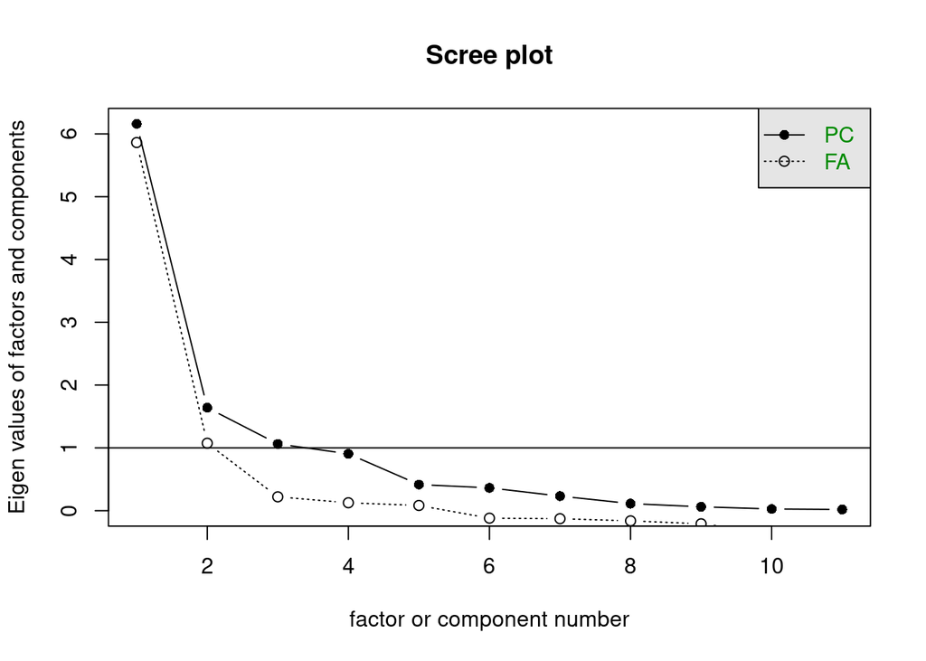

```r
scree(poly_cor)
```

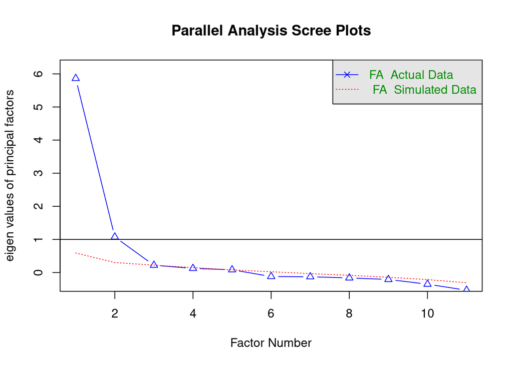

```
## Parallel analysis suggests that the number of factors =  2  and the number of components =  NA
```

```r
fa.parallel(poly_cor,n.obs=200,fa="fa",fm="minres")
```

Estimamos el modelo factorial con 3 factores implementando una rotacion tipo varimax para buscar una interpretación más simple y mostramos la matriz de pesos factorial rotada.

```r
modelo_varimax<-fa(poly_cor,nfactors = 3,rotate = "varimax",
                   fa="mle")
print(modelo_varimax$loadings,cut=0)
```

```
##
## Loadings:
##          MR1    MR2    MR3
## ZPOBDENS  0.013  0.270  0.060
## ZTMINFAN -0.725 -0.608 -0.009
## ZESPVIDA  0.742  0.535  0.084
## ZPOBURB   0.955  0.112  0.041
## ZTMEDICO  0.607  0.531  0.179
## ZPAGRICU -0.975 -0.110 -0.023
## ZPSERVI   0.956 -0.159 -0.242
## ZTLIBROP  0.628  0.436  0.145
## ZTEJERCI  0.000  0.039  0.702
## ZTPOBACT  0.055  0.962 -0.153
## ZTENERGI  0.575  0.584  0.135
##
##                  MR1   MR2   MR3
## SS loadings    4.951 2.518 0.659
## Proportion Var 0.450 0.229 0.060
## Cumulative Var 0.450 0.679 0.739
```

Para verlo más claro vamos a representarlo:

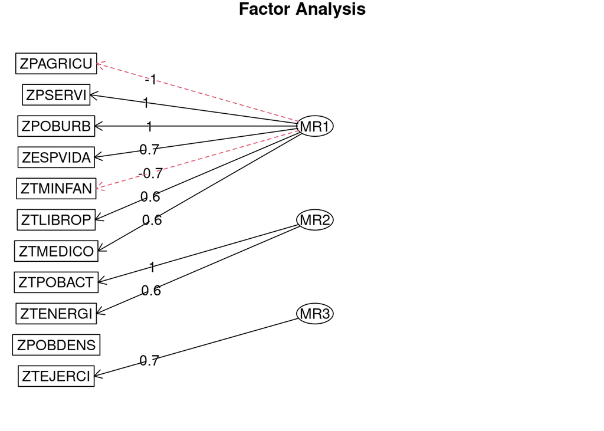

```r
fa.diagram(modelo_varimax)
```

En este diagrama se ve que el primer factor está asociado con ZPSERVI, ZPAGRICU, ZPOBURB, ZESPVIDA, ZTMINFAN, ZTLIBROP y ZTMEDICO. mientras la segunda es con ZTPOBACT y ZTENERGI y la última con ZTEJERCI.

Finalmente comprobamos que en efecto el número de factores elegido es suficiente.

```r
library(stats)
factanal(datos_pca,factors=3, rotation="none")
```

```
##
## Call:
## factanal(x = datos_pca, factors = 3, rotation = "none")
##
## Uniquenesses:
## ZPOBDENS ZTMINFAN ZESPVIDA  ZPOBURB ZTMEDICO ZPAGRICU  ZPSERVI ZTLIBROP
##    0.905    0.023    0.037    0.088    0.316    0.010    0.071    0.417
## ZTEJERCI ZTPOBACT ZTENERGI
##    0.974    0.236    0.042
##
## Loadings:
##          Factor1 Factor2 Factor3
## ZPOBDENS          0.291
## ZTMINFAN -0.893  -0.395   0.154
## ZESPVIDA  0.888   0.354  -0.221
## ZPOBURB   0.930  -0.199
## ZTMEDICO  0.760   0.269   0.185
## ZPAGRICU -0.961   0.255
## ZPSERVI   0.831  -0.455  -0.178
## ZTLIBROP  0.738   0.180
## ZTEJERCI          0.119   0.105
## ZTPOBACT  0.357   0.775   0.186
## ZTENERGI  0.770   0.281   0.535
##
##                Factor1 Factor2 Factor3
## SS loadings      5.915   1.477   0.487
## Proportion Var   0.538   0.134   0.044
## Cumulative Var   0.538   0.672   0.716
##
## Test of the hypothesis that 3 factors are sufficient.
## The chi square statistic is 26.21 on 25 degrees of freedom.
## The p-value is 0.397
```

Con ese p-valor para cierto nivel de confianza se acepta la hipótesis y por tanto el número de factores es suficiente.

# Análisis de la normalidad multivariante

Como en el apartado univariante ya hemos comprobado la normalidad de cada una de las variables no vamos a repetirlo.

El paquete MVN contiene funciones que permiten realizar los tres test que se utilizan habitualmente para contrastar la normalidad multivariante. Esta normalidad multivariante puede verse afectada por la presencia de outliers. En este paquete también encontramos funciones para el análisis de outliers.

```r
library(MVN)
outliers <- mvn(data = datos_pca, mvnTest = "hz", multivariateOutlierMethod = "quan")
```

[figure not shown]

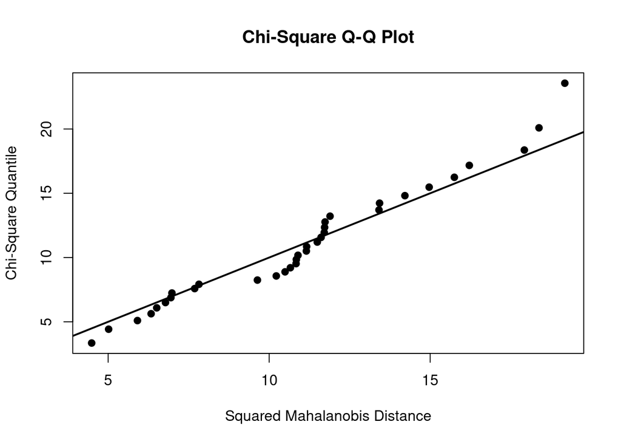

```r
royston_test <- mvn(data = datos_pca, mvnTest = "royston", multivariatePlot = "qq")
```

```r
royston_test$multivariateNormality
```

```
##      Test        H      p value MVN
## 1 Royston 24.07257 7.374655e-05  NO
```

```r
hz_test <- mvn(data = datos_pca, mvnTest = "hz")
hz_test$multivariateNormality
```

```
##            Test        HZ   p value MVN
## 1 Henze-Zirkler 0.9888665 0.0761232 YES
```

Pese a que uno de los test ha rechazado que siga una normal multivariante, vamos a hacerle caso al otro test y seguir, ya que probablemente esto se deba al bajo tamaño de observaciones con el que contamos y en el gráfico los valores no se alejan demasiado de la recta.

# Clasificación

Como acabamos de comprobar la noramlidad multivariante y ya habíamos comprobado la univariante, solo falta la homogeneidad de la varianza.

## Homogeneidad de la varianza

Usaremos el test de Box M, que es una extensión del de Barttlet para escenarios multivariantes. Hay que tener en cuenta que es muy sensible a que los datos efectivamente se distribuyan según una normal multivariante. Por este motivo se recomienda utilizar una significación (p-value) <0.001.

La hipóstesis nula a contrastar es la de igualdad de matrices de covarianzas en todos los grupos.

```r
library(biotools)
#datos_enteros<-read.spss("DB_3.sav", to.data.frame = TRUE)
datos_enteros[15:34,1]<-"china"
datos_enteros[1:15,1]<-"aa"
datos_enteros$PAIS <- as.factor(datos_enteros$PAIS)
col_names <- names(datos_enteros[,2:12])
# to do it for some names in a vector named 'col_names'
datos_enteros[col_names] <- lapply(datos_enteros[col_names] , as.double)
datos_enteros[,1]
```

```
##  [1] aa    aa    aa    aa    aa    aa    aa    aa    aa    aa    aa    aa
## [13] aa    aa    aa    china china china china china china china china china
## [25] china china china china china china china china china china
## Levels: aa china
```

```r
boxM(data = datos_enteros[, 2:12], grouping = datos_enteros[, 1])
```

```
##
##  Box's M-test for Homogeneity of Covariance Matrices
##
## data:  datos_enteros[, 2:12]
## Chi-Sq (approx.) = NA, df = 66, p-value = NA
```

## Mediante análisis discriminante lineal

La función lda del paquete MASS realiza la clasificación.

```r
library(MASS)
continente <- datos_enteros$continente
continente <- as.factor(continente)

modelo_lda <- lda(formula = continente ~ ZPOBDENS + ZTMINFAN, data = datos_enteros[,-1])
modelo_lda
```

```
## Call:
## lda(continente ~ ZPOBDENS + ZTMINFAN, data = datos_enteros[,
##     -1])
##
## Prior probabilities of groups:
##     africa    america       asia     europa    oceania
## 0.14705882 0.17647059 0.35294118 0.29411765 0.02941176
##
## Group means:
##           ZPOBDENS   ZTMINFAN
## africa  -0.6742549  1.3449888
## america -0.9219340 -0.3391427
## asia     0.5598936  0.2636180
## europa   0.3261989 -0.6833203
## oceania -1.0778341 -1.0203009
##
## Coefficients of linear discriminants:
##                LD1        LD2
## ZPOBDENS 0.6469424 -1.0959151
## ZTMINFAN 1.3424019  0.3166111
##
## Proportion of trace:
##    LD1    LD2
## 0.6223 0.3777
```

La salida de este objeto, nos muestra las probabilidades a priori de cada grupo.

Ahora podemos realizar predicciones:

```r
nuevas_observaciones <- data.frame(ZPOBDENS = -0.5, ZTMINFAN = 0.7)
predict(object = modelo_lda, newdata = nuevas_observaciones)
```

```
## $class
## [1] asia
## Levels: africa america asia europa oceania
##
## $posterior
##      africa   america      asia    europa     oceania
## 1 0.2948288 0.1252754 0.4343744 0.1432166 0.002304865
##
## $x
##         LD1       LD2
## 1 0.6162101 0.7695853
```

### Validación

```r
library(biotools)

pred <- predict(modelo_lda, dimen = 1)
confusionmatrix(datos_enteros$continente, pred$class)
```

```
##         new africa new america new asia new europa new oceania
## africa           0           0        5          0           0
## america          0           0        1          5           0
## asia             2           0        7          3           0
## europa           0           0        1          9           0
## oceania          0           0        0          1           0
```

```r
# Porcentaje de errores de clasificación
trainig_error <- mean(datos_enteros$continente != pred$class) * 100
paste("trainig_error=", trainig_error, "%")
```

```
## [1] "trainig_error= 52.9411764705882 %"
```

El error con los datos de training es del 52%, lo cuál es bastante alto.

### Visualización

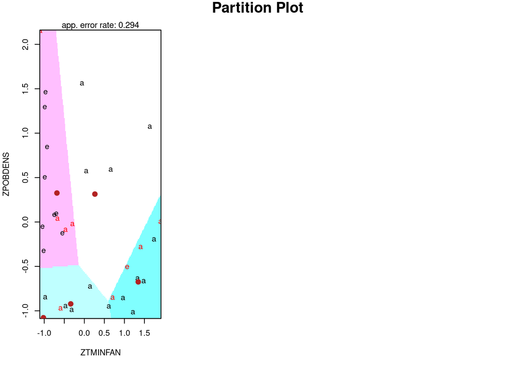

```r
library(klaR)
continente <- datos_enteros$continente
continente <- as.factor(continente)
partimat(continente ~ ZPOBDENS + ZTMINFAN,
         data = datos_pca, method = "lda", prec = 200,
         col.mean = "firebrick",nplots.vert =1, nplots.hor=3)
```

## Mediante análisis discriminante cuadrático

Realizamos ahora análogamente para el modelo cuadrático.

```r
library(MASS)

#modelo_qda <- qda(formula = continente ~ ZPOBDENS + ZTMINFAN, data = datos_enteros[,-1])
#modelo_qda
```